# Introduction

# Introduction

In our database we can find the relations between companies by a parent child relation, but there is a lot of information that can be gained from the total total tree of company relations. This package contains several functions that is useful for extracting this kind of information, and for plotting the total company hierarchy.

### The example data

First let's load the package:

```r
library(graydon.package)
```

The package contains a data frame, *tbl_company_relations* which is an ex(s)ample of how company relations are typically represented in our database (*id_company*, *id_company_parent*), with some extra added data about each of the companies. The data frame contains the following columns:

| Column.names |
| --- |
| id_company |
| id_company_parent |
| code_sbi |
| size_company |
| qty_employees |

# Creating a company hierarchy graph

Company relations in our database are represented in parent-child relations, but this doesn't give you the complete overview of how companies fit together in their complete hierarchy. Graphs provide a way of getting those overviews. Let's load the [*igraph*](http://igraph.org/r/doc/) library first:

```r
library(igraph)
```

With a simple function call we can create a graph, based on those parent-child relationships expressed in a table. Make sure the child and the parent ID columns are the first and second column in the table respectively.

```r
graph_company_hierarchies <- create_graph_company_hierarchies(tbl_company_relations)
```

The resulting graph represents a network of all individual company hierarchies in one big 'space' which can be graphically represented like below. You can see this plot is pretty useless in in itself, but this 'space' of hierarchies can be used as a 'database' to easily retrieve the desired company hierarchies which are usefull for plotting and doing calculations within those.

The *plot_graydon_graph* function is used to plot graphs using graydon colors, the extra parameters *vertex.label*, *vertex.size* and *edge.arrow.size* are set so they override the defaults.

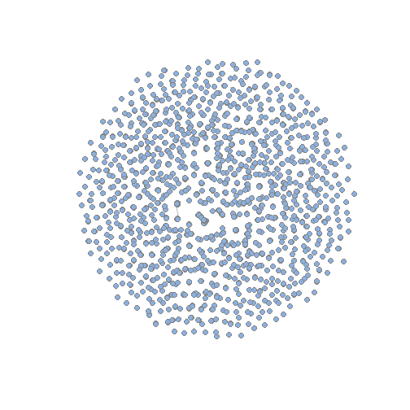

```r
plot_graydon_graph(graph_company_hierarchies,
                   vertex.label = "",
                   vertex.size = 4,
                   edge.arrow.size = 0)
```

# Selecting company hierarchies graphs

There are a few ways which we can select the distinct company hierarchies so we can make useful calculations or plots about them: you can either select them individually or by bulk.

## Selecting a hierarchy by company ID

If you have a single company that you want to find out about more you can select it using the function *find_company_hierarchy*:

```r
id_company_selected <- "931238099"
graph_company_hierarchy <- find_company_hierarchy(graph_company_hierarchies, id_company_selected)
```

The resulting graph has the logical attribute *is_searched_company* set to *TRUE* of the searched for company. Let's plot this graph, highlighting the searched for companies:

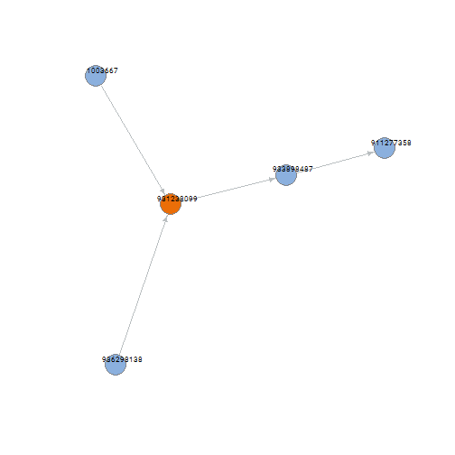

```r
igraph::V(graph_company_hierarchy)$color <- ifelse(igraph::V(graph_company_hierarchy)$is_searched_company,
                                                   col_graydon[2],
                                                   col_graydon[4])
plot_graydon_graph(graph_company_hierarchy)
```

## Selecting hierarchies with a column of company IDs

```r
list_selected_hierarchies <- select_graph_hierarchies(graph_company_hierarchies,
                                                      tbl_customers$id_company)
```

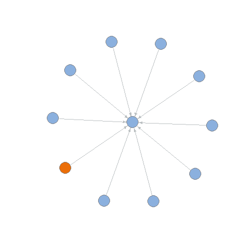

```r
igraph::V(graph_example)$color <- ifelse(igraph::V(graph_example)$is_searched_company,
                                                   col_graydon[2],
                                                   col_graydon[4])
plot_graydon_graph(graph_example, vertex.label = "")
```

## Selecting company neighbourhoods

You can also select parts of company hierarchies by selecting it's neighbourhood. These kinds of graphs are called Neighborhood- or Ego graphs). You can find the neighbourhood of companies with the function *select_ego_graphs*. In this example we are looking for two ego graphs, where are neighbourhood is defined as being two steps away as a maximum (set by the function argument *distance*, where it's default is 1), and we want only the companies (grand)children (as set by the argument *only_children*, which default value is FALSE). Both requested company ID's come from the same company hierarchy, but result in two ego graph's nonetheless.

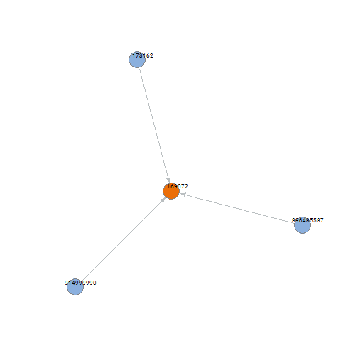

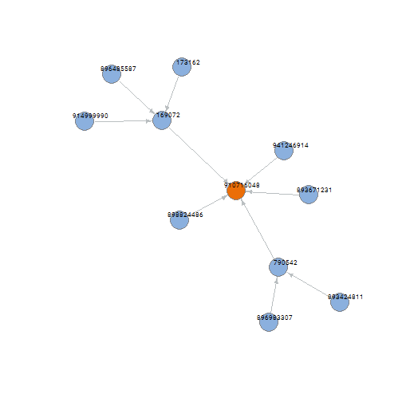

```r
lst_results <- select_ego_graphs(graph_company_hierarchies,
                                 id_companies = c("169072", "910716048"),
                                 distance = 2,
                                 only_children = TRUE)
```

## Listing all hierarchy graphs

For whatever reason, you might want to creating a list of all of the seperate company hierarchies out of the complete company hierarchy 'space'. This will take some time, so take some coffee….

```r
list_all_graphs <- list_company_hierarchy_graphs(graph_company_hierarchies)
```

# Converting company hierarchy graphs to data-frames

Having graphs is nice for creating beautiful plots and useful calculations, but for the data to be useful for further processing, getting data from the graph into a data-frame format is handy.

## Converting a single hierarchy graph

```r
df_single_hierarchy <- hierarchy_as_data_frame(graph_company_hierarchy)
```

| name | id_company_parent | code_sbi | size_company | qty_employees | is_searched_company | color |
| --- | --- | --- | --- | --- | --- | --- |
| 1003667 | 931238099 | 7022 | 2 | 15 | FALSE | #8BB0DE |
| 931238099 | 933898487 | 6420 | 1 | 0 | TRUE | #EB6E08 |
| 933898487 | 911277358 | 7022 | 1 | 0 | FALSE | #8BB0DE |
| 936298138 | 931238099 | 7311 | 2 | 2 | FALSE | #8BB0DE |
| 911277358 | NA | 6420 | 2 | 1 | FALSE | #8BB0DE |

## Converting a list of hierarchy graphs

A list of graphs can also be converted into a data-frame using *hierarchy_list_as_data_frame*:

```r
df_selected_hierarchies <- hierarchy_list_as_data_frame(list_selected_hierarchies)
```

# Calculating properties

## Summing values

Totalling values from across the network can sometimes come in handy for further calculations. You can use the function *total_hierarchy_value* in combination with aggregation functions like *sum*, *mean*, *min* or *median* for this

```r
graph_company_hierarchy <- total_hierarchy_value(graph_company_hierarchy,
                                                 name_attribute = "qty_employees", name_total = "qty_employees_sum",
                                                 FUN = sum, na.rm = TRUE)
```

The result can be found can be shown in a graph, where we can see the original values and the totalled values.

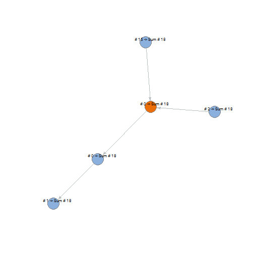

```r
igraph::V(graph_company_hierarchy)$label <- paste0("# ",
                                                   igraph::V(graph_company_hierarchy)$qty_employees,
                                                   " -> Sum # ",
                                                   igraph::V(graph_company_hierarchy)$qty_employees_sum)

plot_graydon_graph(graph_company_hierarchy)
```

## Propagating values

It might come in handy to cumulate values in the hierarchy throughout the network in specific directions (bottom-up, top-down or all directions) and across specific distances. For this purpose you can use the *propagate_hierarchy_value* function.

### Bottom-up all companies

In this example the companies will get a new attribute *qty_employees_cum* which will contain the sum of all the *qty_employees* of the companies that below the company within the hierarchy.

```r
graph_company_hierarchy <- propagate_hierarchy_value(graph = graph_company_hierarchy,
                                                     name_attribute = "qty_employees",
                                                     name_propagate = "qty_employees_cum",
                                                     distance = Inf,
                                                     direction = "in",
                                                     FUN = sum,
                                                     na.rm = TRUE)
```

The result can be found can be shown in a graph, where we can see the original values and the rolled up values.

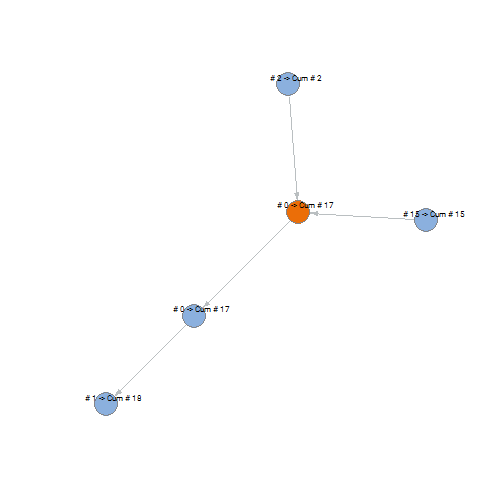

### Top-down 2nd degree companies

In this example the companies will get a new attribute *qty_employees_cum* which will contain the sum of all the *qty_employees* of the companies that are 2 companies up-stream within the hierarchy.

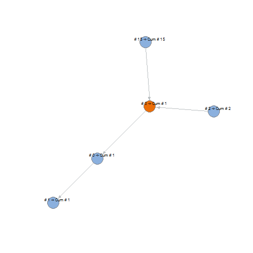

```r
graph_company_hierarchy <- propagate_hierarchy_value(graph = graph_company_hierarchy,
                                                     name_attribute = "qty_employees",
                                                     name_propagate = "qty_employees_cum",
                                                     distance = 2,
                                                     direction = "out",
                                                     FUN = sum,
                                                     na.rm = TRUE)
```

### All directions 1st degree companies

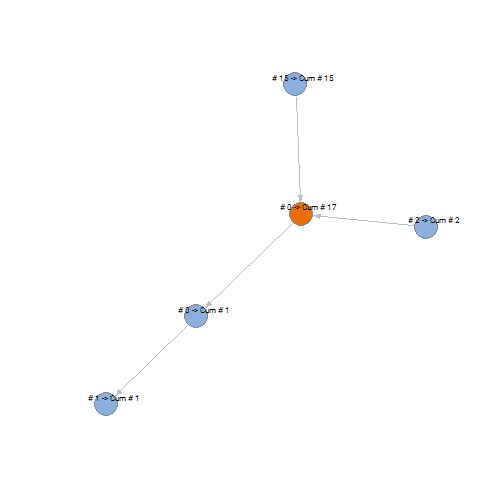

```r
graph_company_hierarchy <- propagate_hierarchy_value(graph = graph_company_hierarchy,
                                                     name_attribute = "qty_employees",
                                                     name_propagate = "qty_employees_cum",
                                                     distance = 1,
                                                     direction = "all",
                                                     FUN = sum,
                                                     na.rm = TRUE)
```

## Adding graph statistics

```r
graph_company_hierarchy <- add_company_hierarchy_stats(graph_company_hierarchy)
```

Let's look at the statistics:

```r
df_single_hierarchy <- hierarchy_as_data_frame(graph_company_hierarchy)
```

| name | id_company_parent | code_sbi | size_company | qty_employees | is_searched_company | qty_employees_sum | qty_employees_cum | is_tree | qty_hierarchy_companies | id_company_top | distance_to_top | qty_child_companies | qty_sister_companies |
| --- | --- | --- | --- | --- | --- | --- | --- | --- | --- | --- | --- | --- | --- |
| 1003667 | 931238099 | 7022 | 2 | 15 | FALSE | 18 | 15 | TRUE | 5 | 911277358 | 3 | 0 | 2 |
| 931238099 | 933898487 | 6420 | 1 | 0 | TRUE | 18 | 17 | TRUE | 5 | 911277358 | 2 | 2 | 1 |
| 933898487 | 911277358 | 7022 | 1 | 0 | FALSE | 18 | 1 | TRUE | 5 | 911277358 | 1 | 1 | 1 |
| 936298138 | 931238099 | 7311 | 2 | 2 | FALSE | 18 | 2 | TRUE | 5 | 911277358 | 3 | 0 | 2 |
| 911277358 | NA | 6420 | 2 | 1 | FALSE | 18 | 1 | TRUE | 5 | 911277358 | 0 | 1 | 0 |

## Marking companies

You can mark companies within a graphthat meet certain categorical criteria with the function *mark_companies_logical*. This can be useful for derivations or coloring graphs. As a somewhat travial example, let's mark the companies that have SBI codes (from *code_sbi*) that are a associated with holdings (that are in the vector *vec_sbi_holdings*). The new company attribute name will be *is_holding*.

```r
vec_sbi_holdings <- c("64", "642", "6420")

graph_company_hierarchy <- mark_companies_logical(graph_company_hierarchy,
                                                  name_logical = "is_holding",
                                                  name_filter = "code_sbi",
                                                  set_criteria = vec_sbi_holdings)
```

## Sister companies

You can get the siblings IDs of a company using the function *get_sibling_ids*, which in turn can be used to mark companies and plot them.

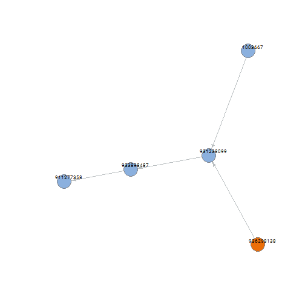

```r
id_siblings <- get_sibling_ids(graph_company_hierarchy, "1003667")

graph_company_hierarchy <- mark_companies_logical(graph_company_hierarchy,
                                                  name_logical = "is_sibling",
                                                  name_filter = "id_company",
                                                  set_criteria = id_siblings
                                                  )

igraph::V(graph_company_hierarchy)$label <- igraph::V(graph_company_hierarchy)$name
V(graph_company_hierarchy)$color <- ifelse(V(graph_company_hierarchy)$is_sibling,
                                                   col_graydon[2],
                                                   col_graydon[4])

plot_graydon_graph(graph_company_hierarchy)
```

Remember the table of customers? If we want to get all siblings of those companies we can use the function *get_siblings_df*.

```r
tbl_siblings <- get_siblings_df(graph_company_hierarchies, tbl_customers$id_company)
```

Below you can see a sample of the resulting data-frame, where you can see the company with it's siblings and the *qty_siblings* indicating the total number of siblings the company of *id_company* has.

| id_company | id_sibling | qty_siblings |
| --- | --- | --- |
| 942286189 | 940892499 | 3 |
| 942286189 | 942694163 | 3 |
| 942286189 | 942695313 | 3 |
| 917758536 | 929312430 | 9 |
| 917758536 | 931364582 | 9 |
| 917758536 | 933317948 | 9 |

## Recoding holdings

When dealing with customers you'll ofen encounter them having economic activity codes that mark them as financial holdings. This is often the case because this is the company you send the bills too. But this is not really informative when analysing the type of companies you have as customers. In this case you might want to recode them to better reflect what kind of business they are really in.

Here you see an example of a company hierarchy with some holdings, which are colored orange here:

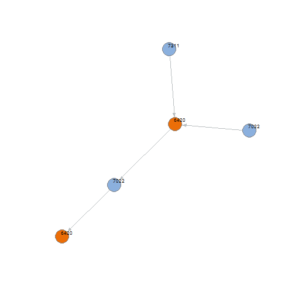

```r
vec_sbi_holdings <- c("64", "642", "6420")

graph_company_hierarchy <- mark_companies_logical(graph_company_hierarchy,
                                                  name_logical = "is_holding",
                                                  name_filter = "code_sbi",
                                                  set_criteria = vec_sbi_holdings)

igraph::V(graph_company_hierarchy)$label <- igraph::V(graph_company_hierarchy)$code_sbi
V(graph_company_hierarchy)$color <- ifelse(V(graph_company_hierarchy)$is_holding,
                                                   col_graydon[2],
                                                   col_graydon[4])

plot_graydon_graph(graph_company_hierarchy)
```

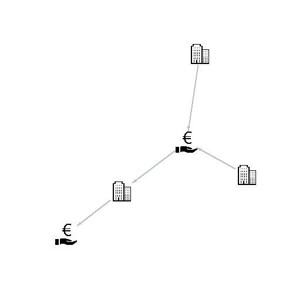

```r
vec_sbi_holdings <- c("64", "642", "6420")
library("png")

img_holding <- readPNG("~/R scripts/hierarchy_changes/money-svg-hand-icon-png-3.png")
img_regular <- readPNG("~/R scripts/hierarchy_changes/vector-apartments-business-building-6.png")

graph_company_hierarchy <- mark_companies_logical(graph_company_hierarchy,
                                                  name_logical = "is_holding",
                                                  name_filter = "code_sbi",
                                                  set_criteria = vec_sbi_holdings)

V(graph_company_hierarchy)$raster <- list(img_regular, img_holding)[V(graph_company_hierarchy)$is_holding+1]

plot_graydon_graph(graph_company_hierarchy,
                   vertex.shape="raster",
                   vertex.label=NA,
                   vertex.size=24,
                   vertex.size2=24,
                   edge.width=2)
```

You can count the number of financial holdings in a company hierarchy like this:

```r
count_companies_by_set(graph = graph_company_hierarchy,
                       name_filter = "code_sbi",
                       set_criteria = vec_sbi_holdings)
```

```
#> [1] 2
```

You can use the function *recode_holding_codes* to recode the holdings so they reflect the economic activity codes of the majority of the children:

```r
graph_company_hierarchy <- recode_holding_codes(graph_company_hierarchy,
                                                name_activity_code = "code_sbi",
                                                vec_holding_codes = c("64", "642", "6420"))
```

This would result in this recoded company hierarchy:

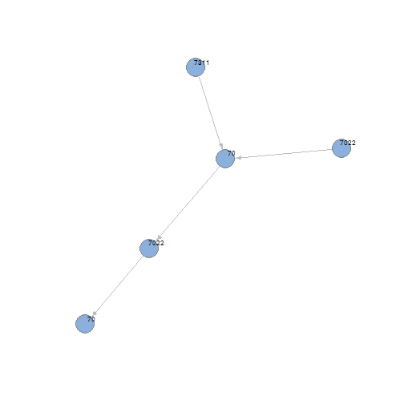